# Mixed Models for Trust and Self Efficacy

## Graph 2: Mixed Model Effects for Mean Trust Value

Trust Value Models: Which variable would best explain the differences across the participants? Result: Using the reliability and complexity seem to reduce the RMSE and R^2, but the reliability has a lower AIC value, so I decided to proceed with reliability in the model to avoid overfitting. Moreover, the complexity models did not seem to converge. Having the reliability in the slope interaction raises the R2 value from .397 to .68 and including reliability in the model raises it to the .80 range which signifies the importance of these effects. The interpretation of this model is that the slope interaction from reliabiltiy indicates that people’s response to trust (whether they go up a little or a lot) is a slope (random effect), but the fixed effect is that they all generally move in the same direction (high to low trust when going from high to low reliability).

```r
MLID.lame = lme4::lmer(mean_trust_value ~ (1|ID),
   data = f.df)

MLr.lame = lme4::lmer(mean_trust_value ~ (reliability|ID),
   data = f.df)

#MLc.lame = lme4::lmer(mean_trust_value ~ (complexity|ID),
    #data = f.df) #not converging
#MLcc.lame = lme4::lmer(mean_trust_value ~ complexity + (complexity|ID),
   #data = f.df)  #not converging

MLrr.lame = lme4::lmer(mean_trust_value ~ reliability + (1|ID),
   data = f.df)

MLrr2.lame = lme4::lmer(mean_trust_value ~ reliability + (reliability|ID),
data = f.df)  #this model produced the best results, but it does not make sense to have a categorical vairable be both fixed and random in a model: muscardinus.be/2017/08/fixed-and-random/#fit-with-lme4

MLree.lame = lme4::lmer(mean_trust_value ~ exposure+ (reliability|ID),
   data = f.df)

MLree2.lame = lme4::lmer(mean_trust_value ~ exposure*reliability+ (reliability|ID),
   data = f.df) #this model produced the best results, but it does not make sense to have a categorical vairable be both fixed and random in a model: muscardinus.be/2017/08/fixed-and-random/#fit-with-lme4

MLree3.lame = lme4::lmer(mean_trust_value ~ exposure*reliability+ (1|ID),
   data = f.df)

trust.table = compare_performance(MLID.lame,MLr.lame,MLrr.lame, MLree.lame , MLrr2.lame, MLree2.lame, MLree3.lame, rank = TRUE)
trust.table
```

```
# Comparison of Model Performance Indices

Name        |   Model |     AIC |     BIC | R2 (cond.) | R2 (marg.) |   ICC |  RMSE | Sigma | Performance-Score
---------------------------------------------------------------------------------------------------------------
MLree2.lame | lmerMod | 481.127 | 508.092 |      0.837 |      0.291 | 0.769 | 0.479 | 0.538 |           100.00%
MLrr2.lame  | lmerMod | 493.298 | 513.522 |      0.812 |      0.269 | 0.743 | 0.510 | 0.568 |            93.96%
MLr.lame    | lmerMod | 516.002 | 532.856 |      0.683 |      0.000 | 0.683 | 0.507 | 0.569 |            70.98%
MLree.lame  | lmerMod | 521.080 | 541.304 |      0.681 |  2.375e-06 | 0.681 | 0.507 | 0.571 |            69.76%
MLree3.lame | lmerMod | 543.483 | 563.707 |      0.716 |      0.288 | 0.601 | 0.668 | 0.711 |            69.56%
MLrr.lame   | lmerMod | 551.152 | 564.635 |      0.683 |      0.269 | 0.566 | 0.699 | 0.740 |            63.85%
MLID.lame   | lmerMod | 671.377 | 681.489 |      0.397 |      0.000 | 0.397 | 0.971 | 1.021 |             0.00%
```

## Fit and report model

```r
BEST.lame = lme4::lmer(mean_trust_value ~ reliability*exposure + (reliability|ID),
data = f.df)

summary(BEST.lame)## Report
```

```
Linear mixed model fit by REML ['lmerMod']
Formula: mean_trust_value ~ reliability * exposure + (reliability | ID)
   Data: f.df

REML criterion at convergence: 465.1

Scaled residuals:
    Min      1Q  Median      3Q     Max
-3.3386 -0.3876  0.0419  0.4404  3.9195

Random effects:
 Groups   Name           Variance Std.Dev. Corr
 ID       (Intercept)    0.6933   0.8326
          reliabilitylow 0.7684   0.8766   -0.08
 Residual                0.2890   0.5376
Number of obs: 215, groups:  ID, 24

Fixed effects:
                         Estimate Std. Error t value
(Intercept)               5.52383    0.18622  29.663
reliabilitylow           -1.09998    0.20976  -5.244
exposure2                 0.24212    0.09949   2.434
reliabilitylow:exposure2 -0.80398    0.17118  -4.697

Correlation of Fixed Effects:
            (Intr) rlblty expsr2
reliabltylw -0.213
exposure2   -0.313  0.280
rlbltylw:x2  0.184 -0.291 -0.585
```

```r
report(BEST.lame)
```

[output not shown]

## Graph 3: Plot model parameters and effect size

```r
model_parameters(BEST.lame)
```

```
# Fixed Effects

Parameter                        | Coefficient |   SE |         95% CI | t(207) |      p
----------------------------------------------------------------------------------------
(Intercept)                      |        5.52 | 0.19 | [ 5.16,  5.89] |  29.66 | < .001
reliability [low]                |       -1.10 | 0.21 | [-1.51, -0.69] |  -5.24 | < .001
exposure [2]                     |        0.24 | 0.10 | [ 0.05,  0.44] |   2.43 | 0.015
reliability [low] * exposure [2] |       -0.80 | 0.17 | [-1.14, -0.47] |  -4.70 | < .001

# Random Effects

Parameter               | Coefficient
-------------------------------------
SD (Intercept: ID)      |        0.83
SD (reliabilitylow: ID) |        0.88
Cor (Intercept~ID)      |       -0.08
SD (Residual)           |        0.73
```

```r
effectsize(BEST.lame)
```

```
# Standardization method: refit

Parameter                | Coefficient (std.) |         95% CI
--------------------------------------------------------------
(Intercept)              |               0.29 | [ 0.01,  0.57]
reliabilitylow           |              -0.84 | [-1.16, -0.53]
exposure2                |               0.19 | [ 0.04,  0.34]
reliabilitylow:exposure2 |              -0.62 | [-0.87, -0.36]
```

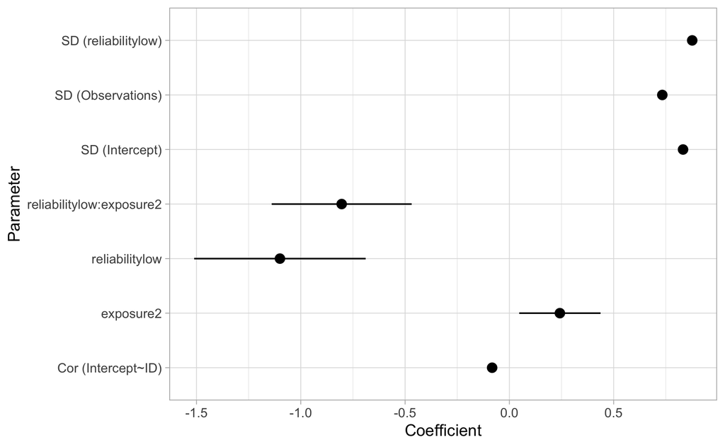

```r
parameters.df = model_parameters(BEST.lame)%>%
  as.data.frame()

dot.plot =ggplot(parameters.df %>% filter(Parameter !="(Intercept)"),aes(Coefficient, Parameter))+  geom_pointrange(aes(xmin = CI_low, xmax = CI_high))+  theme_light()
dot.plot
```

```r
NA
NA
```

## Graph 4: Plot model-based mean

```r
means.df
```

[output not shown]

```r
estimate_means(BEST.lame)
```

```
Estimated Marginal Means

reliability | exposure | Mean |   SE |       95% CI
---------------------------------------------------
high        |        1 | 5.52 | 0.19 | [5.14, 5.91]
low         |        1 | 4.42 | 0.25 | [3.91, 4.94]
high        |        2 | 5.77 | 0.18 | [5.39, 6.14]
low         |        2 | 3.86 | 0.27 | [3.31, 4.41]

Marginal means estimated for reliability, exposure
```

```r
estimate_contrasts(BEST.lame)
```

```
Marginal Contrasts Analysis

Level1 | Level2 | Difference |         95% CI |   SE |     df |     t |      p
------------------------------------------------------------------------------
high 1 | high 2 |      -0.24 | [-0.51,  0.02] | 0.10 | 168.74 | -2.43 | 0.075
high 1 |  low 1 |       1.10 | [ 0.50,  1.70] | 0.21 |  27.24 |  5.23 | < .001
high 1 |  low 2 |       1.66 | [ 1.01,  2.31] | 0.23 |  39.44 |  7.13 | < .001
high 2 |  low 2 |       1.90 | [ 1.26,  2.54] | 0.23 |  37.50 |  8.30 | < .001
low 1  | high 2 |      -1.34 | [-1.93, -0.75] | 0.21 |  25.14 | -6.52 | < .001
low 1  |  low 2 |       0.56 | [ 0.19,  0.93] | 0.14 | 172.82 |  4.03 | < .001

Marginal contrasts estimated for reliability, exposure
p-value adjustment method: Holm (1979)
```

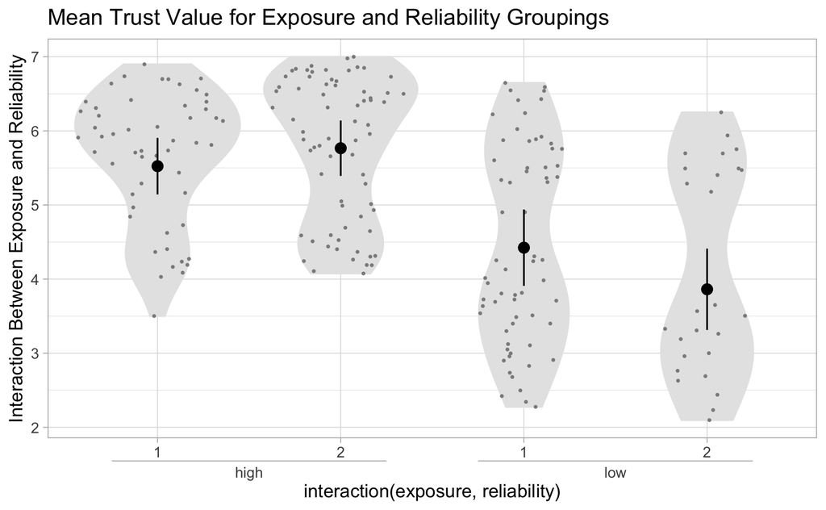

```r
means.df = estimate_means(BEST.lame) %>% as.data.frame()
sina.plot =
ggplot(rel.df, aes(interaction(exposure, reliability), mean))+
  geom_hline(yintercept = mean(rel.df$mean), colour ="grey85")+
  geom_violin(colour ="grey90", fill ="grey90")+
  geom_sina(colour ="grey55", size =.4) +
  ylab("Mean Trust Value") +
  ylab("Interaction Between Exposure and Reliability") +
  geom_pointrange(data = means.df, aes(interaction(exposure, reliability), Mean, ymin = CI_low,
ymax = CI_high))+  theme_light() + ggtitle("Mean Trust Value for Exposure and Reliability Groupings") +
  guides(x = "axis_nested")

sina.plot
```

```r
NA
NA
```

## Self Efficacy Models: Which variable would best explain the differences across the participants?

Result: The complexity has comparable measures to reliability in BIC, RMSE and R^2, but complexity seems to reduce the AIC. The complexity may matter more in the measurement of self efficacy

## Prepare the data

```r
stemp = f.df %>%
  group_by(ID, reliability, exposure, event) %>%
  select(exposure, reliability, ID, SSE_1, event) %>%
  summarise(exposure, reliability, ID, event, mean = mean(SSE_1, na.rm = TRUE)) %>%
  distinct(exposure, reliability, ID, event, mean)
```

[output not shown]

## Visualize the data

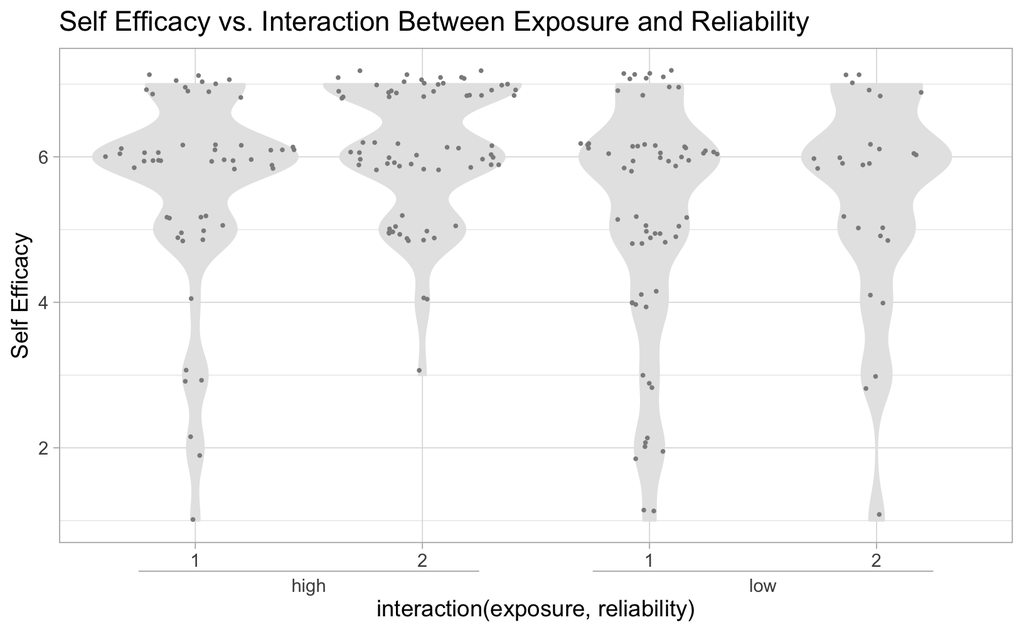

```r
ggplot(stemp, aes(interaction(exposure, reliability), mean))+
  geom_violin(colour ="grey90", fill ="grey90")+
  geom_sina(colour ="grey55", size =.4)+
  theme_light() +
  ylab("Self Efficacy") +
  ggtitle("Self Efficacy vs. Interaction Between Exposure and Reliability") +
  guides(x = "axis_nested")
```

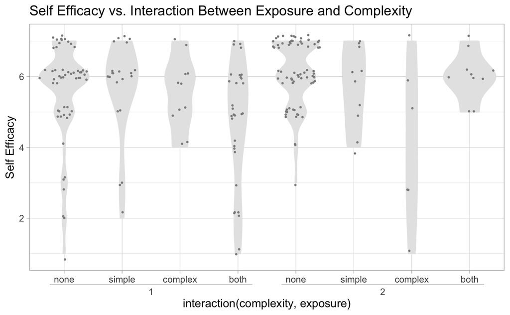

```r
ggplot(stemp2, aes(interaction(complexity, exposure), mean)) +
  geom_violin(colour ="grey90", fill ="grey90") +
  geom_sina(colour ="grey55", size =.4)+
  theme_light() +
  ylab("Self Efficacy") +
  ggtitle("Self Efficacy vs. Interaction Between Exposure and Complexity") +
  guides(x = "axis_nested")
```

```r
NA
NA
```

## Mixed Model Effects for Self Efficacy

Self Efficacy Models: Which variable would best explain the differences across the participants in predicting self-efficacy throughout the experiment?

```r
SML1.lame = lme4::lmer(SSE_1 ~ (1|ID), data = f.df)
SML2.lame = lme4::lmer(SSE_1 ~  complexity + (1|ID), data = f.df)
SML3.lame = lme4::lmer(SSE_1 ~ reliability + (reliability|ID), data = f.df)
SML4.lame = lme4::lmer(SSE_1 ~ reliability + exposure + (reliability|ID), data = f.df)
SML45.lame = lme4::lmer(SSE_1 ~ reliability*exposure + (reliability|ID), data = f.df)
SML5.lame = lme4::lmer(SSE_1 ~ reliability*exposure + complacency_value + (reliability|ID),data = f.df)
SML6.lame = lme4::lmer(SSE_1 ~ reliability*exposure + efficacy_value + (reliability|ID),data = f.df)
SML7.lame = lme4::lmer(SSE_1 ~ reliability*exposure + efficacy_value*complacency_value + (reliability|ID),data = f.df)

efficacy.table = compare_performance(SML1.lame, SML2.lame, SML3.lame,SML4.lame, SML45.lame, SML5.lame, SML6.lame, SML7.lame, rank = TRUE)
```

```
When comparing models, please note that probably not all models were fit from same data.
```

```r
efficacy.table
```

```
# Comparison of Model Performance Indices

Name       |   Model |     AIC |     BIC | R2 (cond.) | R2 (marg.) |   ICC |  RMSE | Sigma | Performance-Score
--------------------------------------------------------------------------------------------------------------
SML7.lame  | lmerMod | 552.971 | 587.970 |      0.684 |      0.141 | 0.632 | 0.798 | 0.885 |            91.09%
SML6.lame  | lmerMod | 550.847 | 579.483 |      0.665 |      0.133 | 0.613 | 0.799 | 0.885 |            88.70%
SML5.lame  | lmerMod | 551.101 | 579.737 |      0.646 |      0.095 | 0.609 | 0.798 | 0.886 |            83.27%
SML4.lame  | lmerMod | 633.720 | 657.315 |      0.646 |      0.081 | 0.615 | 0.752 | 0.831 |            69.53%
SML45.lame | lmerMod | 635.549 | 662.514 |      0.646 |      0.083 | 0.614 | 0.750 | 0.831 |            68.83%
SML3.lame  | lmerMod | 639.084 | 659.307 |      0.627 |      0.066 | 0.600 | 0.777 | 0.854 |            61.23%
SML2.lame  | lmerMod | 649.210 | 669.434 |      0.551 |      0.082 | 0.511 | 0.877 | 0.932 |            34.68%
SML1.lame  | lmerMod | 673.641 | 683.753 |      0.464 |      0.000 | 0.464 | 0.962 | 1.013 |             0.00%
```

```r
SBEST.lame = lme4::lmer(SSE_1 ~ reliability*exposure + efficacy_value*complacency_value + (reliability|ID),data = f.df)

summary(SBEST.lame)## Report
```

```
Linear mixed model fit by REML ['lmerMod']
Formula: SSE_1 ~ reliability * exposure + efficacy_value * complacency_value +      (reliability | ID)
   Data: f.df

REML criterion at convergence: 531

Scaled residuals:
    Min      1Q  Median      3Q     Max
-3.4944 -0.3306  0.0632  0.3437  3.1405

Random effects:
 Groups   Name           Variance Std.Dev. Corr
 ID       (Intercept)    0.9195   0.9589
          reliabilitylow 0.8533   0.9237   0.10
 Residual                0.7837   0.8852
Number of obs: 178, groups:  ID, 20

Fixed effects:
                                 Estimate Std. Error t value
(Intercept)                       -2.6743     7.5151  -0.356
reliabilitylow                    -0.5724     0.2813  -2.035
exposure2                          0.5387     0.1781   3.025
efficacy_value                     1.7681     1.5778   1.121
complacency_value                  2.0212     2.5327   0.798
reliabilitylow:exposure2          -0.2844     0.3117  -0.912
efficacy_value:complacency_value  -0.4470     0.5206  -0.859

Correlation of Fixed Effects:
            (Intr) rlblty expsr2 effcc_ cmplc_ rlbl:2
reliabltylw -0.015
exposure2   -0.024  0.369
efficacy_vl -0.971  0.002  0.000
cmplcncy_vl -0.978  0.007  0.008  0.950
rlbltylw:x2  0.016 -0.389 -0.579 -0.001 -0.007
effccy_vl:_  0.958 -0.001  0.002 -0.983 -0.976  0.000
```

```r
report(SBEST.lame)
```

[output not shown]

```r
## Plot model parameters and effect size
model_parameters(SBEST.lame)
```

```
# Fixed Effects

Parameter                          | Coefficient |   SE |          95% CI | t(167) |     p
------------------------------------------------------------------------------------------
(Intercept)                        |       -2.67 | 7.52 | [-17.40, 12.06] |  -0.36 | 0.722
reliability [low]                  |       -0.57 | 0.28 | [ -1.12, -0.02] |  -2.03 | 0.042
exposure [2]                       |        0.54 | 0.18 | [  0.19,  0.89] |   3.02 | 0.002
efficacy_value                     |        1.77 | 1.58 | [ -1.32,  4.86] |   1.12 | 0.262
complacency_value                  |        2.02 | 2.53 | [ -2.94,  6.99] |   0.80 | 0.425
reliability [low] * exposure [2]   |       -0.28 | 0.31 | [ -0.90,  0.33] |  -0.91 | 0.362
efficacy_value * complacency_value |       -0.45 | 0.52 | [ -1.47,  0.57] |  -0.86 | 0.391

# Random Effects

Parameter               | Coefficient
-------------------------------------
SD (Intercept: ID)      |        0.96
SD (reliabilitylow: ID) |        0.92
Cor (Intercept~ID)      |        0.10
SD (Residual)           |        0.94
```

```r
effectsize(SBEST.lame)
```

```
# Standardization method: refit

Parameter                        | Coefficient (std.) |         95% CI
----------------------------------------------------------------------
(Intercept)                      |               0.05 | [-0.30,  0.39]
reliabilitylow                   |              -0.40 | [-0.78, -0.01]
exposure2                        |               0.37 | [ 0.13,  0.61]
efficacy_value                   |               0.14 | [-0.23,  0.52]
complacency_value                |              -0.12 | [-0.50,  0.26]
reliabilitylow:exposure2         |              -0.20 | [-0.62,  0.23]
efficacy_value:complacency_value |              -0.11 | [-0.34,  0.13]
```

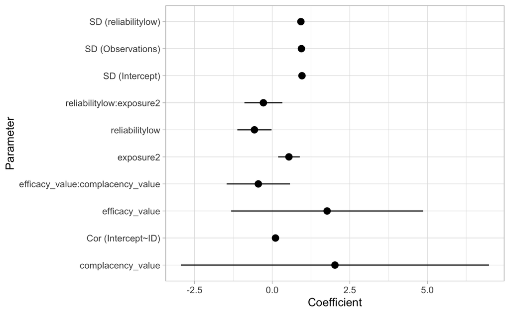

```r
parameters.df = model_parameters(SBEST.lame)%>%
  as.data.frame()

dot.plot =ggplot(parameters.df %>% filter(Parameter !="(Intercept)"),aes(Coefficient, Parameter))+  geom_pointrange(aes(xmin = CI_low, xmax = CI_high))+  theme_light()
dot.plot
```

```r
NA
NA
```

## Plot model-based mean

```r
estimate_means(SBEST.lame)
```

```
Estimated Marginal Means

reliability | exposure | Mean |   SE |       95% CI
---------------------------------------------------
high        |        1 | 5.56 | 0.26 | [5.03, 6.09]
low         |        1 | 4.99 | 0.34 | [4.27, 5.71]
high        |        2 | 6.10 | 0.25 | [5.58, 6.61]
low         |        2 | 5.24 | 0.39 | [4.44, 6.04]

Marginal means estimated for reliability, exposure
```

```r
estimate_contrasts(SBEST.lame)
```

```
Marginal Contrasts Analysis

Level1 | Level2 | Difference |         95% CI |   SE |     df |     t |     p
-----------------------------------------------------------------------------
high 1 | high 2 |      -0.54 | [-1.02, -0.06] | 0.18 | 141.13 | -3.02 | 0.016
high 1 |  low 1 |       0.57 | [-0.23,  1.38] | 0.28 |  26.46 |  2.03 | 0.204
high 1 |  low 2 |       0.32 | [-0.61,  1.25] | 0.34 |  46.44 |  0.94 | 0.783
high 2 |  low 2 |       0.86 | [-0.06,  1.77] | 0.33 |  44.49 |  2.59 | 0.060
low 1  | high 2 |      -1.11 | [-1.90, -0.33] | 0.27 |  23.25 | -4.08 | 0.002
low 1  |  low 2 |      -0.25 | [-0.94,  0.43] | 0.26 | 146.65 | -0.99 | 0.753

Marginal contrasts estimated for reliability, exposure
p-value adjustment method: Holm (1979)
```

```r
smeans.df = estimate_means(SBEST.lame) %>% as.data.frame()
```

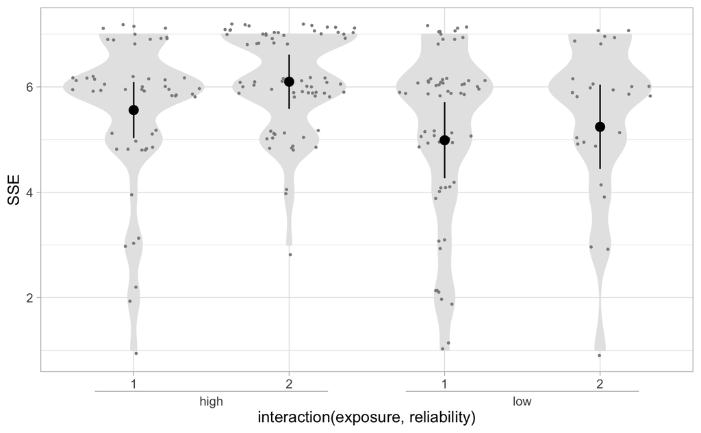

```r
ssina.plot =
ggplot(stemp, aes(interaction(exposure, reliability), mean))+
  geom_hline(yintercept = mean(stemp$mean), colour ="grey85")+
  geom_violin(colour ="grey90", fill ="grey90")+
  geom_sina(colour ="grey55", size =.4)+
  geom_pointrange(data = smeans.df, aes(interaction(exposure, reliability), Mean, ymin = CI_low,
ymax = CI_high))+  theme_light() + ylab("SSE") +
  guides(x = "axis_nested")


ssina.plot
```

## Investigation into Variables that Influence Reliability and Exposure

Result: Complexity did provide the best model by having a lower RMSE and AIC. This is important because the added complexity to the model seems to have a pay-off for measurement of self-efficacy.

```r
SLID.lame = lme4::lmer(SSE_1 ~ (1|ID),
   data = f.df)

SLre.lame = lme4::lmer(SSE_1 ~  reliability + (1|ID),
   data = f.df)

SBEST.lame = lme4::lmer(SSE_1 ~  complexity + (1|ID), #best model
   data = f.df)

SLexpo.lame = lme4::lmer(SSE_1 ~  exposure + (1|ID),
   data = f.df)

SLeve.lame = lme4::lmer(SSE_1 ~ event + (1|ID),
   data = f.df)

ASBEST.lame = lme4::lmer(SSE_1 ~  complexity + (complexity|ID), #best model
   data = f.df) #best
```

```
boundary (singular) fit: see ?isSingular
```

```r
#BSBEST.lame = lme4::lmer(SSE_1 ~  complexity + (reliability|ID), #best model
   #data = f.df) #does not work

compare_performance(SLID.lame, SLre.lame, SBEST.lame, SLexpo.lame, SLeve.lame, ASBEST.lame, rank = TRUE)
```

```
Random effect variances not available. Returned R2 does not account for random effects.
```

```
Following indices with missing values are not used for ranking: R2_conditional, ICC
```

```
# Comparison of Model Performance Indices

Name        |   Model |     AIC |     BIC | R2 (marg.) |  RMSE | Sigma | Performance-Score
------------------------------------------------------------------------------------------
ASBEST.lame | lmerMod | 635.545 | 686.105 |      0.250 | 0.677 | 0.771 |            87.35%
SBEST.lame  | lmerMod | 649.210 | 669.434 |      0.082 | 0.877 | 0.932 |            51.05%
SLre.lame   | lmerMod | 652.103 | 665.585 |      0.062 | 0.898 | 0.949 |            47.76%
SLexpo.lame | lmerMod | 663.362 | 676.844 |      0.036 | 0.927 | 0.979 |            29.29%
SLID.lame   | lmerMod | 673.641 | 683.753 |      0.000 | 0.962 | 1.013 |            12.49%
SLeve.lame  | lmerMod | 681.162 | 698.016 |  3.737e-04 | 0.961 | 1.018 |             0.05%
```

```r
SBASELINE.lame = lme4::lmer(SSE_1 ~ reliability + (reliability|ID),
   data = f.df)

SML1.lame = lme4::lmer(SSE_1 ~ (reliability|ID),
   data = f.df)

SML2.lame = lme4::lmer(SSE_1 ~ exposure + (reliability|ID),
   data = f.df)

SBEST.lame = lme4::lmer(SSE_1 ~ reliability + exposure + (reliability|ID),
   data = f.df)

SML4.lame = lme4::lmer(SSE_1 ~ reliability*exposure + (reliability|ID) ,
   data = f.df)

SML6.lame = lme4::lmer(SSE_1 ~ reliability*exposure + (reliability|ID) + (exposure|ID),
   data = f.df)
```

```
unable to evaluate scaled gradientModel failed to converge: degenerate  Hessian with 1 negative eigenvalues
```

```r
compare_performance(SBASELINE.lame, SML1.lame, SML2.lame, SBEST.lame, SML4.lame,  SML6.lame)
```

```
# Comparison of Model Performance Indices

Name           |   Model |     AIC |     BIC | R2 (cond.) | R2 (marg.) |   ICC |  RMSE | Sigma
----------------------------------------------------------------------------------------------
SBASELINE.lame | lmerMod | 639.084 | 659.307 |      0.627 |      0.066 | 0.600 | 0.777 | 0.854
SML1.lame      | lmerMod | 645.728 | 662.581 |      0.543 |      0.000 | 0.543 | 0.773 | 0.854
SML2.lame      | lmerMod | 637.084 | 657.308 |      0.566 |      0.031 | 0.552 | 0.749 | 0.831
SBEST.lame     | lmerMod | 633.720 | 657.315 |      0.646 |      0.081 | 0.615 | 0.752 | 0.831
SML4.lame      | lmerMod | 635.549 | 662.514 |      0.646 |      0.083 | 0.614 | 0.750 | 0.831
SML6.lame      | lmerMod | 638.653 | 675.730 |      0.575 |      0.107 | 0.525 | 0.713 | 0.805
```

## Combination of different measures of individuals

```r
SBASELINE.lame = lme4::lmer(SSE_1 ~ reliability + exposure + (reliability|ID),
   data = f.df)

SMLEP.lame = lme4::lmer(SSE_1 ~ reliability*exposure + efficacy_value+ propensity_value + (reliability|ID),
   data = f.df)

SBEST.lame = lme4::lmer(SSE_1 ~ reliability*exposure + efficacy_value+ complacency_value + (reliability|ID),
   data = f.df)

SMLCP.lame = lme4::lmer(SSE_1 ~ reliability*exposure + propensity_value + complacency_value + (reliability|ID),
   data = f.df)

SMLCPE.lame = lme4::lmer(SSE_1 ~ reliability*exposure + propensity_value + complacency_value + efficacy_value + (reliability|ID),
   data = f.df)

SMLEP2.lame = lme4::lmer(SSE_1 ~ reliability*exposure + efficacy_value*propensity_value + (reliability|ID),
   data = f.df)

SMLEC2.lame = lme4::lmer(SSE_1 ~ reliability*exposure + efficacy_value*complacency_value + (reliability|ID),
   data = f.df)

SMLCP2.lame = lme4::lmer(SSE_1 ~ reliability*exposure + propensity_value*complacency_value + (reliability|ID),
   data = f.df)

SMLCPE2.lame = lme4::lmer(SSE_1 ~ reliability*exposure + propensity_value*complacency_value*efficacy_value + (reliability|ID),
   data = f.df)

compare_performance(SBASELINE.lame,SMLEP.lame, SBEST.lame, SMLCP.lame ,SMLCPE.lame ,SMLEP2.lame, SMLEC2.lame, SMLCP2.lame, SMLCPE2.lame)
```

[output not shown]

```r
#Go with complexity because it seems to explain more of the variance

MLID.lame = lme4::lmer(mean_trust_value ~ (1|ID),
   data = f.df)

BEST.lame = lme4::lmer(mean_trust_value ~  reliability + (1|ID),#best model
   data = f.df)

MLcomp.lame = lme4::lmer(mean_trust_value ~  complexity + (1|ID),
   data = f.df)

MLexpo.lame = lme4::lmer(mean_trust_value ~  exposure + (1|ID),
   data = f.df)

MLeve.lame = lme4::lmer(mean_trust_value ~ event + (1|ID),
   data = f.df)

compare_performance(MLID.lame, BEST.lame, MLcomp.lame, MLexpo.lame, MLeve.lame, rank = TRUE)
```

```
# Comparison of Model Performance Indices

Name        |   Model |     AIC |     BIC | R2 (cond.) | R2 (marg.) |   ICC |  RMSE | Sigma | Performance-Score
---------------------------------------------------------------------------------------------------------------
BEST.lame   | lmerMod | 551.152 | 564.635 |      0.683 |      0.269 | 0.566 | 0.699 | 0.740 |            98.97%
MLcomp.lame | lmerMod | 554.042 | 574.266 |      0.685 |      0.277 | 0.564 | 0.692 | 0.736 |            98.51%
MLexpo.lame | lmerMod | 670.061 | 683.543 |      0.413 |      0.015 | 0.404 | 0.957 | 1.009 |             6.44%
MLID.lame   | lmerMod | 671.377 | 681.489 |      0.397 |      0.000 | 0.397 | 0.971 | 1.021 |             3.05%
MLeve.lame  | lmerMod | 678.896 | 695.749 |      0.394 |  3.430e-04 | 0.394 | 0.971 | 1.026 |             0.02%
```

## Investigate if reliability has a slope effect as well.

Result: the slope effect of reliability seems to reduce the AIC, RMSE and increase the R^2.

```r
BASELINE.lame = lme4::lmer(mean_trust_value ~  reliability + (1|ID),
   data = f.df)

BEST.lame = lme4::lmer(mean_trust_value ~ reliability + (reliability|ID),
   data = f.df) #lowest AIC and lowest RMSE and highest R^2

MLA.lame3 = lme4::lmer(mean_trust_value ~ (1|ID) + (1|exposure),
   data = f.df)

compare_performance(BASELINE.lame, BEST.lame,  MLA.lame3, rank = TRUE)
```

```
# Comparison of Model Performance Indices

Name          |   Model |     AIC |     BIC | R2 (cond.) | R2 (marg.) |   ICC |  RMSE | Sigma | Performance-Score
-----------------------------------------------------------------------------------------------------------------
BEST.lame     | lmerMod | 493.298 | 513.522 |      0.812 |      0.269 | 0.743 | 0.510 | 0.568 |            99.99%
BASELINE.lame | lmerMod | 551.152 | 564.635 |      0.683 |      0.269 | 0.566 | 0.699 | 0.740 |            66.97%
MLA.lame3     | lmerMod | 670.656 | 684.138 |      0.419 |      0.000 | 0.419 | 0.957 | 1.009 |             0.00%
```

## Investigate if there is an interaction between reliability and exposure.

Result: There is an interaction effect between the reliability and the exposure.

```r
BASELINE.lame = lme4::lmer(mean_trust_value ~ reliability + (reliability|ID),
   data = f.df) #lowest AIC and lowest RMSE and highest R^2

ML1.lame = lme4::lmer(mean_trust_value ~ (reliability|ID),
   data = f.df)

ML2.lame = lme4::lmer(mean_trust_value ~ exposure + (reliability|ID),
   data = f.df)

ML3.lame = lme4::lmer(mean_trust_value ~ reliability + (reliability|ID),
   data = f.df)

ML4.lame = lme4::lmer(mean_trust_value ~ reliability + exposure + (reliability|ID),
   data = f.df)

BEST.lame = lme4::lmer(mean_trust_value ~ reliability*exposure + (reliability|ID) ,
   data = f.df) #best model with lowest AIC and keeping RMSE low

ML6.lame = lme4::lmer(mean_trust_value ~ reliability*exposure + (reliability|ID) + (exposure|ID),
   data = f.df)
```

```
boundary (singular) fit: see ?isSingular
```

```r
compare_performance(BASELINE.lame, ML1.lame, ML2.lame, ML3.lame, ML4.lame, BEST.lame, ML6.lame)
```

```
# Comparison of Model Performance Indices

Name          |   Model |     AIC |     BIC | R2 (cond.) | R2 (marg.) |   ICC |  RMSE | Sigma
---------------------------------------------------------------------------------------------
BASELINE.lame | lmerMod | 493.298 | 513.522 |      0.812 |      0.269 | 0.743 | 0.510 | 0.568
ML1.lame      | lmerMod | 516.002 | 532.856 |      0.683 |      0.000 | 0.683 | 0.507 | 0.569
ML2.lame      | lmerMod | 521.080 | 541.304 |      0.681 |  2.375e-06 | 0.681 | 0.507 | 0.571
ML3.lame      | lmerMod | 493.298 | 513.522 |      0.812 |      0.269 | 0.743 | 0.510 | 0.568
ML4.lame      | lmerMod | 498.241 | 521.835 |      0.811 |      0.270 | 0.742 | 0.510 | 0.570
BEST.lame     | lmerMod | 481.127 | 508.092 |      0.837 |      0.291 | 0.769 | 0.479 | 0.538
ML6.lame      | lmerMod | 486.878 | 523.955 |      0.733 |      0.480 | 0.487 | 0.479 | 0.537
```

## Determine if efficacy, propensity, and complacency have an influence on the mean trust

```r
BASELINE.lame = lme4::lmer(mean_trust_value ~ reliability*exposure + (reliability|ID),
   data = f.df)

MLE.lame = lme4::lmer(mean_trust_value ~ reliability*exposure + efficacy_value+ (reliability|ID),
   data = f.df)

MLP.lame = lme4::lmer(mean_trust_value ~ reliability*exposure + propensity_value+ (reliability|ID),
   data = f.df)

MLEE.lame = lme4::lmer(mean_trust_value ~ reliability*exposure*efficacy_value + (reliability|ID),
   data = f.df)

MLEP.lame = lme4::lmer(mean_trust_value ~ reliability*exposure*propensity_value + (reliability|ID),
   data = f.df)

MLEC.lame = lme4::lmer(mean_trust_value ~ reliability*exposure*complacency_value + (reliability|ID),
   data = f.df)

compare_performance(BASELINE.lame, MLE.lame, MLP.lame,BEST.lame, MLEE.lame, MLEP.lame, MLEC.lame)
```

```
When comparing models, please note that probably not all models were fit from same data.
```

```
# Comparison of Model Performance Indices

Name          |   Model |     AIC |     BIC | R2 (cond.) | R2 (marg.) |   ICC |  RMSE | Sigma
---------------------------------------------------------------------------------------------
BASELINE.lame | lmerMod | 481.127 | 508.092 |      0.837 |      0.291 | 0.769 | 0.479 | 0.538
MLE.lame      | lmerMod | 421.485 | 450.121 |      0.831 |      0.337 | 0.746 | 0.510 | 0.573
MLP.lame      | lmerMod | 421.270 | 449.906 |      0.830 |      0.336 | 0.745 | 0.510 | 0.573
BEST.lame     | lmerMod | 481.127 | 508.092 |      0.837 |      0.291 | 0.769 | 0.479 | 0.538
MLEE.lame     | lmerMod | 429.038 | 467.219 |      0.834 |      0.339 | 0.748 | 0.506 | 0.573
MLEP.lame     | lmerMod | 429.709 | 467.891 |      0.830 |      0.336 | 0.744 | 0.510 | 0.577
MLEC.lame     | lmerMod | 426.568 | 464.750 |      0.830 |      0.319 | 0.750 | 0.510 | 0.577
```

## Combination of different measures of individuals

```r
BASELINE.lame = lme4::lmer(mean_trust_value ~ reliability*exposure + complacency_value+ (reliability|ID),
   data = f.df)

MLEP.lame = lme4::lmer(mean_trust_value ~ reliability*exposure + efficacy_value+ propensity_value + (reliability|ID),
   data = f.df)

MLEC.lame = lme4::lmer(mean_trust_value ~ reliability*exposure + efficacy_value+ complacency_value + (reliability|ID),
   data = f.df)

MLCP.lame = lme4::lmer(mean_trust_value ~ reliability*exposure + propensity_value + complacency_value + (reliability|ID),
   data = f.df)

MLCPE.lame = lme4::lmer(mean_trust_value ~ reliability*exposure + propensity_value + complacency_value + efficacy_value + (reliability|ID),
   data = f.df)

MLEP2.lame = lme4::lmer(mean_trust_value ~ reliability*exposure + efficacy_value*propensity_value + (reliability|ID),
   data = f.df)

MLEC2.lame = lme4::lmer(mean_trust_value ~ reliability*exposure + efficacy_value*complacency_value + (reliability|ID),
   data = f.df)

MLCP2.lame = lme4::lmer(mean_trust_value ~ reliability*exposure + propensity_value*complacency_value + (reliability|ID),
   data = f.df)

BEST.lame = lme4::lmer(mean_trust_value ~ reliability*exposure + propensity_value*complacency_value*efficacy_value + (reliability|ID),
   data = f.df)

compare_performance(BASELINE.lame, MLEP.lame, MLEC.lame ,MLEC.lame,  MLCP.lame,MLCPE.lame, MLEP2.lame, MLEC2.lame ,MLEC2.lame,  MLCP2.lame,BEST.lame)
```

[output not shown]